# Lab 1: Data Visualization, Expected Value and Covariance Properties

Catarina Loureiro & M. Rosário Oliveira - Multivariate Analysis (LMAC/MECD/MMAC/Minor-CD)

setembro 2024

List of useful `R` libraries:

```r
library(readr)
library(dplyr)
library(ggplot2)
library(psych)
library(car)
library(GGally)
library(mvtnorm)
library(kableExtra)
library(robustbase)
library(rrcov)
library(knitr)
library(plotrix)
library(RColorBrewer)
library(MASS)
library(corrplot)
```

## Example: Exploratory Data Analysis

The `iris` dataset is available in `R` and contains measurements on 4 different attributes for 50 flowers from 3 different species. For more information on this dataset see: https://archive.ics.uci.edu/dataset/53/iris.

### 1. Basic Summary Statistics

```r
data("iris")
head(iris)
```

|  | Sepal.Length | Sepal.Width | Petal.Length | Petal.Width | Species |
| --- | --- | --- | --- | --- | --- |
| 1 | 5.1 | 3.5 | 1.4 | 0.2 | setosa |
| 2 | 4.9 | 3.0 | 1.4 | 0.2 | setosa |
| 3 | 4.7 | 3.2 | 1.3 | 0.2 | setosa |
| 4 | 4.6 | 3.1 | 1.5 | 0.2 | setosa |
| 5 | 5.0 | 3.6 | 1.4 | 0.2 | setosa |
| 6 | 5.4 | 3.9 | 1.7 | 0.4 | setosa |

```r
summary(iris)
```

```
##   Sepal.Length    Sepal.Width     Petal.Length    Petal.Width
##  Min.   :4.300   Min.   :2.000   Min.   :1.000   Min.   :0.100
##  1st Qu.:5.100   1st Qu.:2.800   1st Qu.:1.600   1st Qu.:0.300
##  Median :5.800   Median :3.000   Median :4.350   Median :1.300
##  Mean   :5.843   Mean   :3.057   Mean   :3.758   Mean   :1.199
##  3rd Qu.:6.400   3rd Qu.:3.300   3rd Qu.:5.100   3rd Qu.:1.800
##  Max.   :7.900   Max.   :4.400   Max.   :6.900   Max.   :2.500
##        Species
##  setosa    :50
##  versicolor:50
##  virginica :50
##
##
##
```

```r
describe(iris)
```

|  | vars | n | mean | sd | median | trimmed | mad | min | max | range | skew | kurtosis | se |
| --- | --- | --- | --- | --- | --- | --- | --- | --- | --- | --- | --- | --- | --- |
| Sepal.Length | 1 | 150 | 5.843333 | 0.8280661 | 5.80 | 5.808333 | 1.03782 | 4.3 | 7.9 | 3.6 | 0.3086407 | -0.6058125 | 0.06761132 |
| Sepal.Width | 2 | 150 | 3.057333 | 0.4358663 | 3.00 | 3.043333 | 0.44478 | 2.0 | 4.4 | 2.4 | 0.3126147 | 0.1387047 | 0.03558833 |
| Petal.Length | 3 | 150 | 3.758000 | 1.7652982 | 4.35 | 3.760000 | 1.85325 | 1.0 | 6.9 | 5.9 | -0.2694109 | -1.4168574 | 0.14413600 |
| Petal.Width | 4 | 150 | 1.199333 | 0.7622377 | 1.30 | 1.184167 | 1.03782 | 0.1 | 2.5 | 2.4 | -0.1009166 | -1.3581792 | 0.06223645 |
| Species* | 5 | 150 | 2.000000 | 0.8192319 | 2.00 | 2.000000 | 1.48260 | 1.0 | 3.0 | 2.0 | 0.0000000 | -1.5199333 | 0.06689001 |

```r
describeBy(iris[,1:4], group=iris$Species)
```

```
##
##  Descriptive statistics by group
## group: setosa
##              vars  n mean   sd median trimmed  mad min max range skew kurtosis
## Sepal.Length    1 50 5.01 0.35    5.0    5.00 0.30 4.3 5.8   1.5 0.11    -0.45
## Sepal.Width     2 50 3.43 0.38    3.4    3.42 0.37 2.3 4.4   2.1 0.04     0.60
## Petal.Length    3 50 1.46 0.17    1.5    1.46 0.15 1.0 1.9   0.9 0.10     0.65
## Petal.Width     4 50 0.25 0.11    0.2    0.24 0.00 0.1 0.6   0.5 1.18     1.26
##                se
## Sepal.Length 0.05
## Sepal.Width  0.05
## Petal.Length 0.02
## Petal.Width  0.01
## ------------------------------------------------------------
## group: versicolor
##              vars  n mean   sd median trimmed  mad min max range  skew kurtosis
## Sepal.Length    1 50 5.94 0.52   5.90    5.94 0.52 4.9 7.0   2.1  0.10    -0.69
## Sepal.Width     2 50 2.77 0.31   2.80    2.78 0.30 2.0 3.4   1.4 -0.34    -0.55
## Petal.Length    3 50 4.26 0.47   4.35    4.29 0.52 3.0 5.1   2.1 -0.57    -0.19
## Petal.Width     4 50 1.33 0.20   1.30    1.32 0.22 1.0 1.8   0.8 -0.03    -0.59
##                se
## Sepal.Length 0.07
## Sepal.Width  0.04
## Petal.Length 0.07
## Petal.Width  0.03
## ------------------------------------------------------------
## group: virginica
##              vars  n mean   sd median trimmed  mad min max range  skew kurtosis
## Sepal.Length    1 50 6.59 0.64   6.50    6.57 0.59 4.9 7.9   3.0  0.11    -0.20
## Sepal.Width     2 50 2.97 0.32   3.00    2.96 0.30 2.2 3.8   1.6  0.34     0.38
## Petal.Length    3 50 5.55 0.55   5.55    5.51 0.67 4.5 6.9   2.4  0.52    -0.37
## Petal.Width     4 50 2.03 0.27   2.00    2.03 0.30 1.4 2.5   1.1 -0.12    -0.75
##                se
## Sepal.Length 0.09
## Sepal.Width  0.05
## Petal.Length 0.08
## Petal.Width  0.04
```

```r
table(iris$Species)
```

```
##
##     setosa versicolor  virginica
##         50         50         50
```

```r
round(table(iris$Species)/length(iris$Species),3)
```

```
##
##     setosa versicolor  virginica
##      0.333      0.333      0.333
```

```r
round(quantile(iris[,1],probs = seq(0,1,0.2)),3)
```

```
##   0%  20%  40%  60%  80% 100%
## 4.30 5.00 5.60 6.10 6.52 7.90
```

### 2. Association Among Variables

```r
round(var(iris[,1:4]),3)
```

```
##              Sepal.Length Sepal.Width Petal.Length Petal.Width
## Sepal.Length        0.686      -0.042        1.274       0.516
## Sepal.Width        -0.042       0.190       -0.330      -0.122
## Petal.Length        1.274      -0.330        3.116       1.296
## Petal.Width         0.516      -0.122        1.296       0.581
```

```r
round(cov(iris[,1:4]),3)
```

```
##              Sepal.Length Sepal.Width Petal.Length Petal.Width
## Sepal.Length        0.686      -0.042        1.274       0.516
## Sepal.Width        -0.042       0.190       -0.330      -0.122
## Petal.Length        1.274      -0.330        3.116       1.296
## Petal.Width         0.516      -0.122        1.296       0.581
```

```r
round(cor(iris[,1:4]),3)
```

```
##              Sepal.Length Sepal.Width Petal.Length Petal.Width
## Sepal.Length        1.000      -0.118        0.872       0.818
## Sepal.Width        -0.118       1.000       -0.428      -0.366
## Petal.Length        0.872      -0.428        1.000       0.963
## Petal.Width         0.818      -0.366        0.963       1.000
```

### 3. Data Visualization

Usually, problems are characterized by a high (huge) number of variables or features, and humans live in three dimensions. The challenge is to find a meaningful representation of the data that reveals interesting patterns, existing in the data.

See The R Graph Gallery in https://www.r-graph-gallery.com/ or the R CHARTS in https://r-charts.com/. You can check more information about the R Graph Gallery in https://bookdown.org/content/b298e479-b1ab-49fa-b83d-a57c2b034d49/.

#### 3.1 Univariate Data: Qualitative Variables

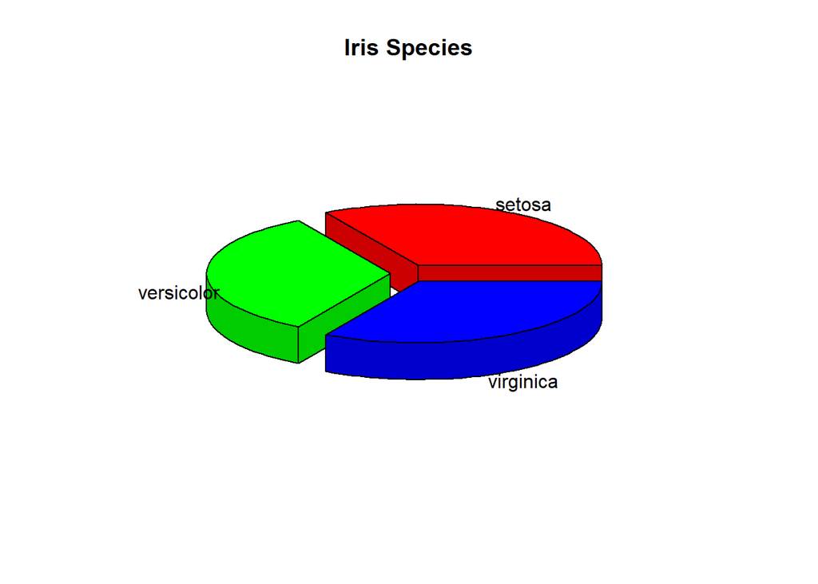

```r
# 3D Exploded Pie Chart
library(plotrix)

pie3D(as.vector(table(iris$Species)),labels=unique(iris$Species),explode=0.1,main="Iris Species",labelcex=1.0)
```

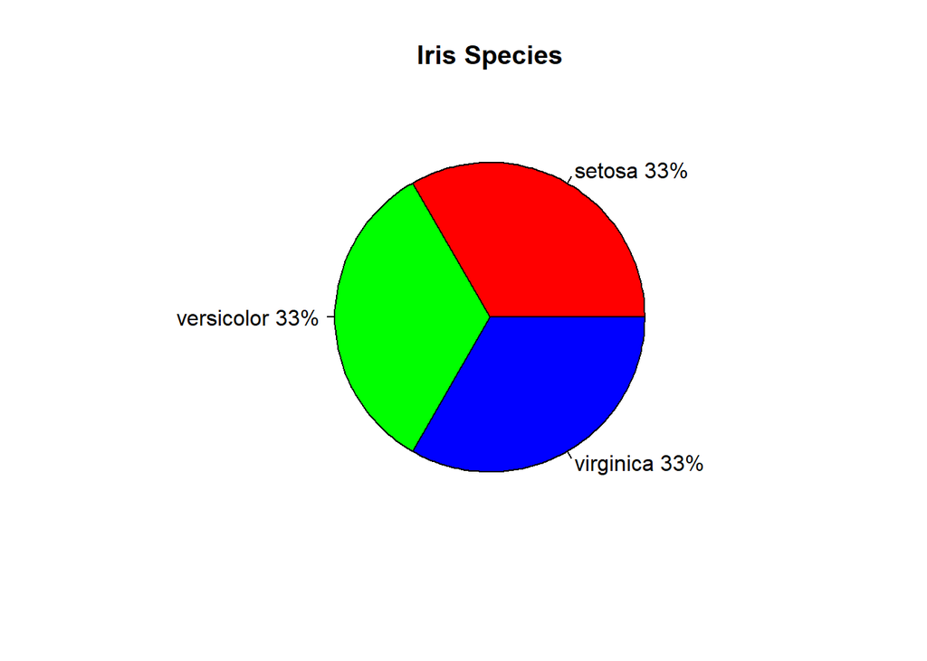

```r
# Pie Chart with Percentages
slices <- as.vector(table(iris$Species))
lbls <- names(table(iris$Species))
pct <- round(slices/sum(slices)*100)
lbls <- paste(lbls, pct) # add percents to labels
lbls <- paste(lbls,"%",sep="") # ad % to labels
pie(slices,labels = lbls, col=rainbow(length(lbls)),main="Iris Species")
```

#### 3.2 Univariate Data: Quantitative Variables

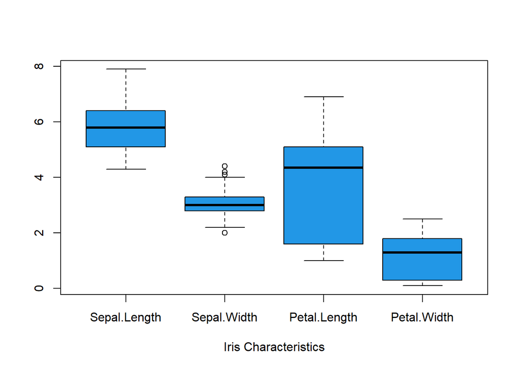

```r
boxplot(iris[,1:4],col=4,prob=TRUE,xlab="Iris Characteristics")
```

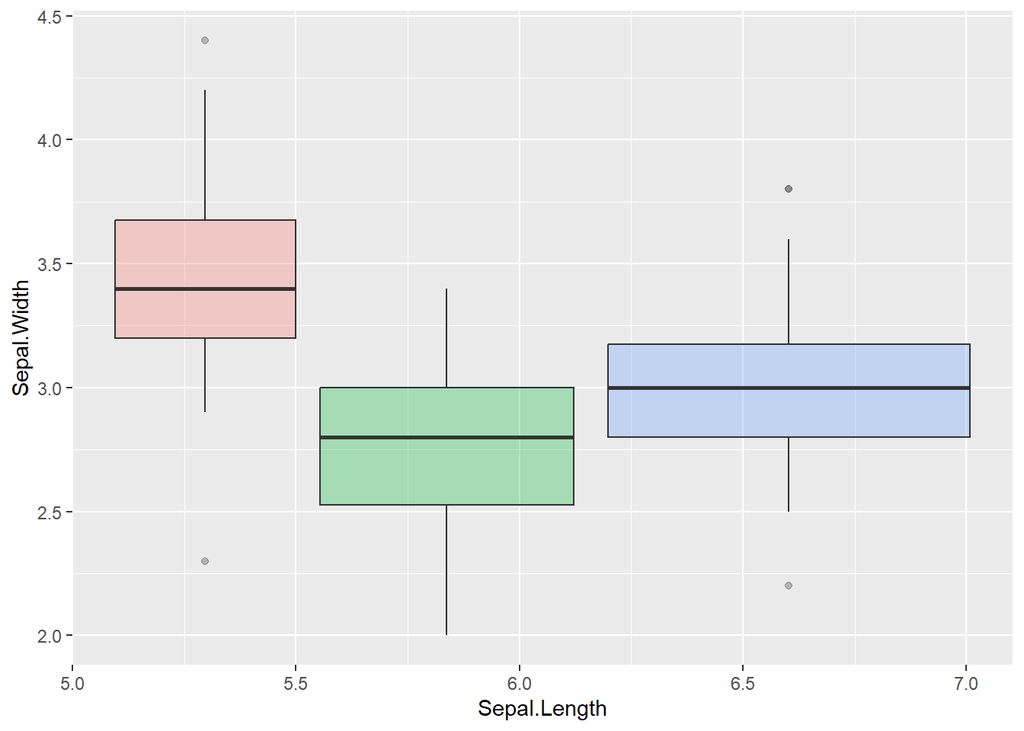

```r
ggplot(iris, aes(x=Sepal.Length, y=Sepal.Width, fill=Species)) +
geom_boxplot(alpha=0.3) + theme(legend.position="none")
```

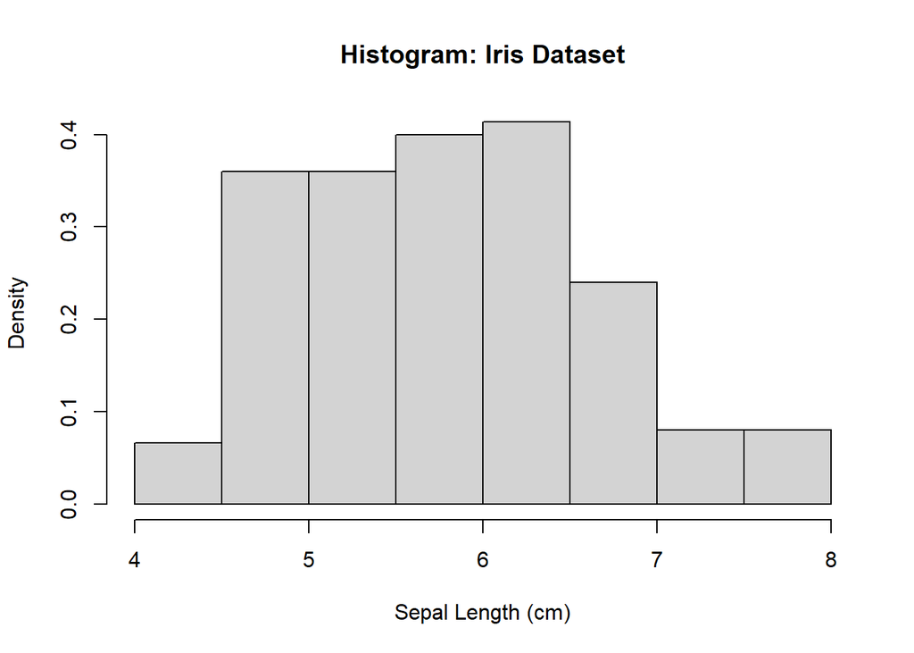

```r
hist(iris$Sepal.Length,prob=TRUE,xlab="Sepal Length (cm)",main="Histogram: Iris Dataset")
```

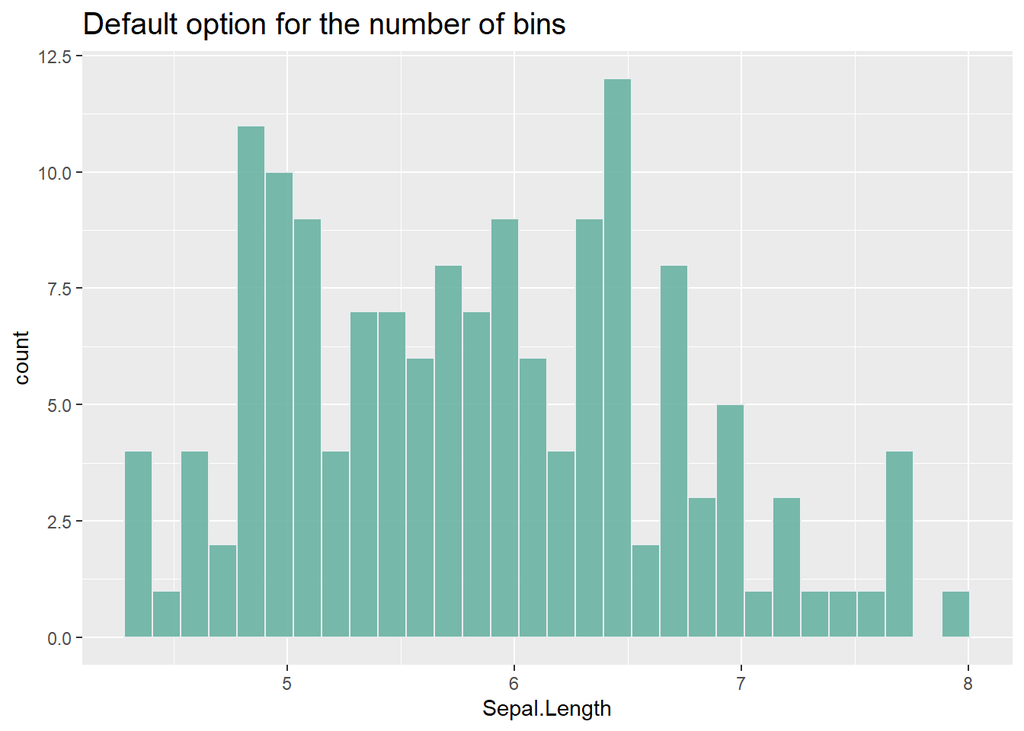

```r
ggplot(iris, aes(x=Sepal.Length)) +
geom_histogram( fill="#69b3a2", color="#e9ecef", alpha=0.9) +
ggtitle("Default option for the number of bins") +
theme(plot.title = element_text(size=15))
```

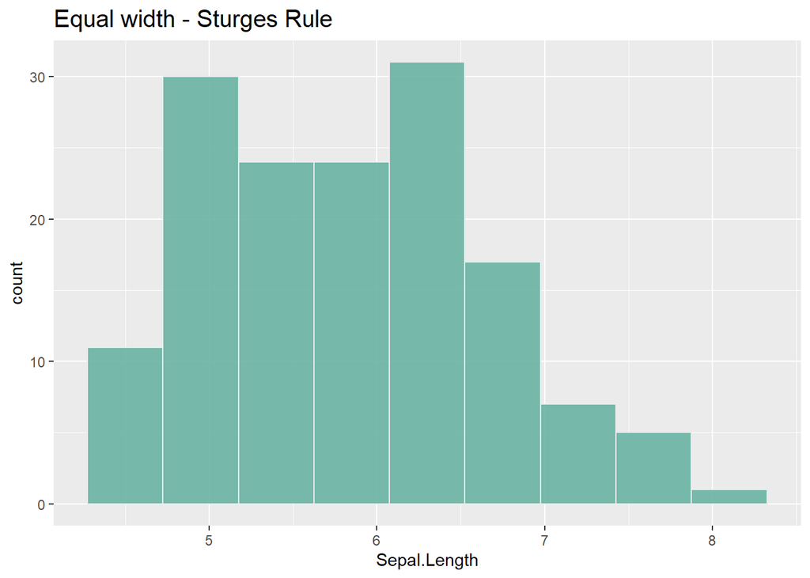

```r
k<-floor(1+log(nrow(iris))/log(2))
delta<-(range(iris$Sepal.Length)[2]-range(iris$Sepal.Length)[1])/k

ggplot(iris, aes(x=Sepal.Length)) +
geom_histogram( binwidth=delta, fill="#69b3a2", color="#e9ecef", alpha=0.9) +
ggtitle("Equal width - Sturges Rule") +
theme(plot.title = element_text(size=15))
```

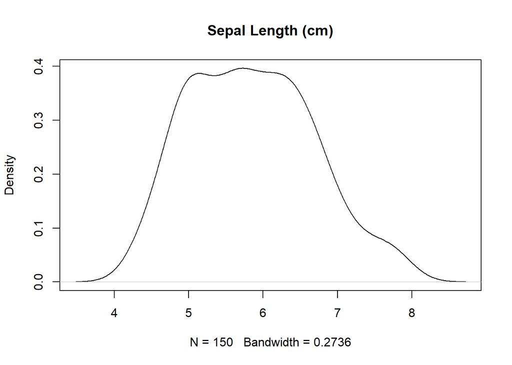

```r
plot(density(iris$Sepal.Length), main="Sepal Length (cm)")
```

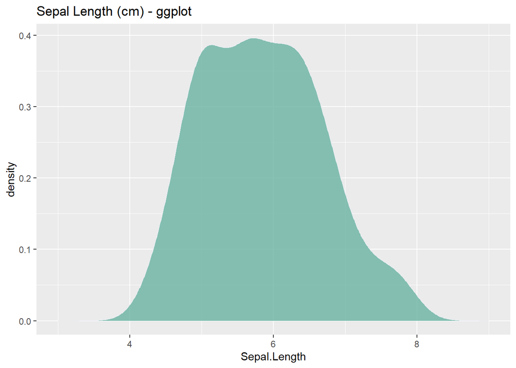

```r
ggplot(iris, aes(x=Sepal.Length)) +
geom_density(fill="#69b3a2", color="#e9ecef", alpha=0.8) +
xlim(3,9) + ggtitle("Sepal Length (cm) - ggplot")
```

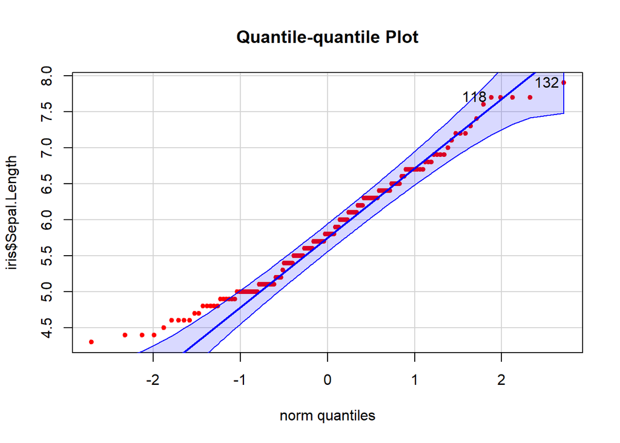

```
## [1] 132 118
```

```r
qqPlot(iris$Sepal.Length,distribution = "norm",main="Quantile-quantile Plot",pch=20,col="red")
```

#### 3.3 Bivariate Data and Correlations

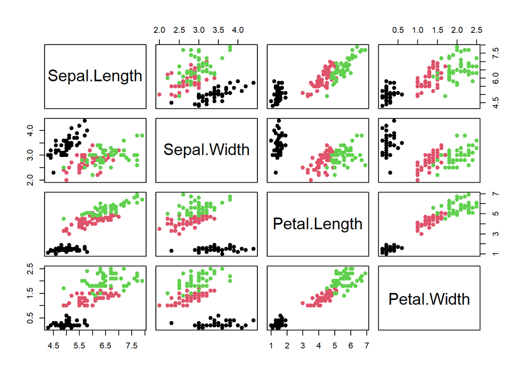

```r
pairs(iris[,1:4],col=(iris$Species),pch=19)
```

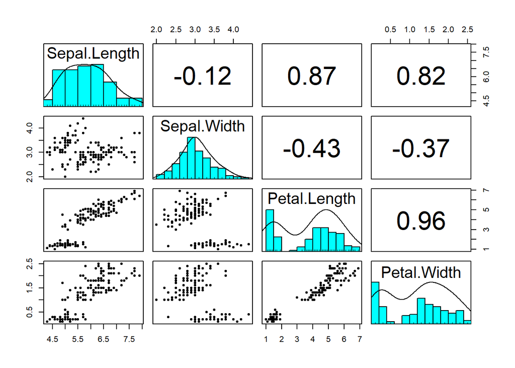

```r
pairs.panels(iris[,1:4], smooth = FALSE, scale = FALSE, density=TRUE,ellipses=FALSE,digits=2)
```

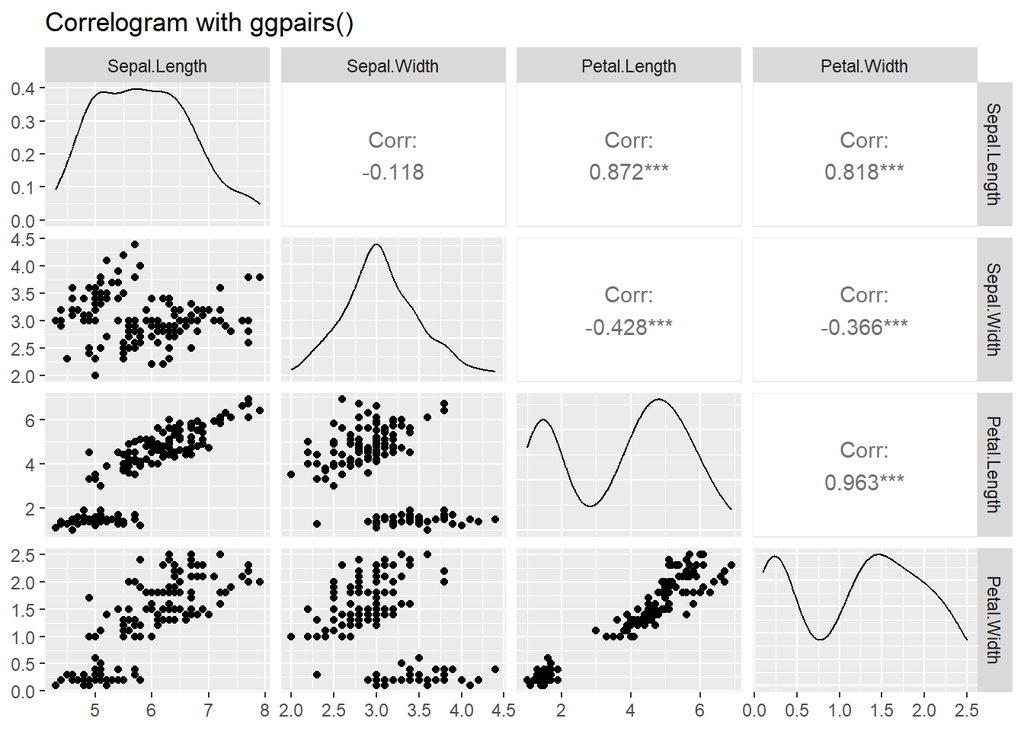

```r
ggpairs(iris[,1:4], title="Correlogram with ggpairs()")
```

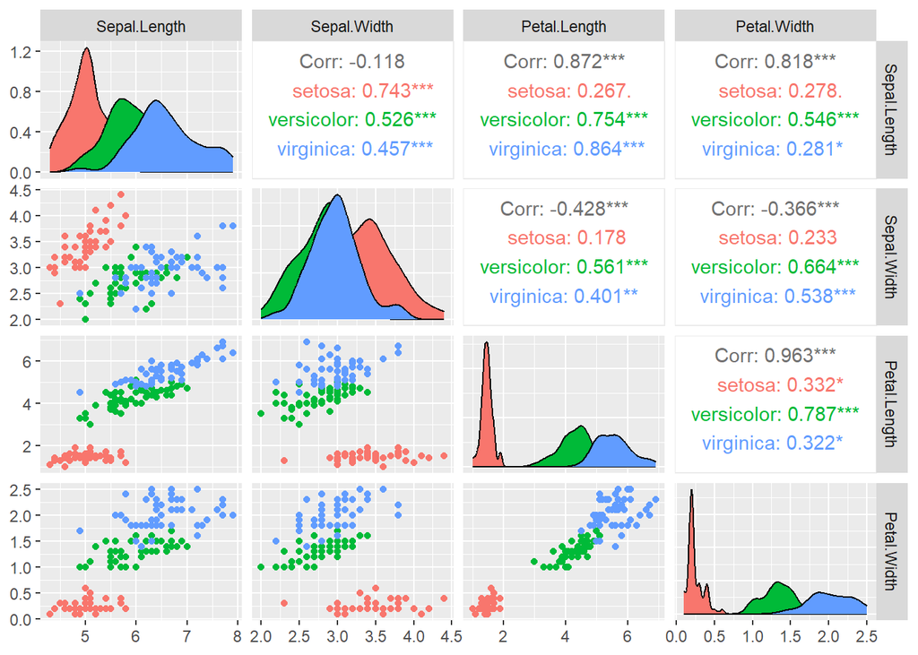

```r
ggpairs(iris[,1:4], columns = 1:4, ggplot2::aes(colour=iris$Species))
```

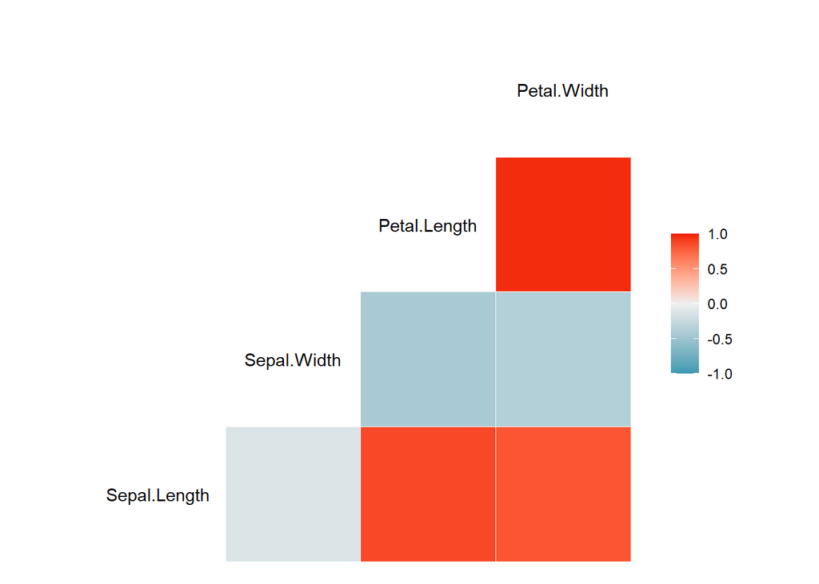

```r
ggcorr(iris[,1:4], method = c("everything", "pearson"))
```

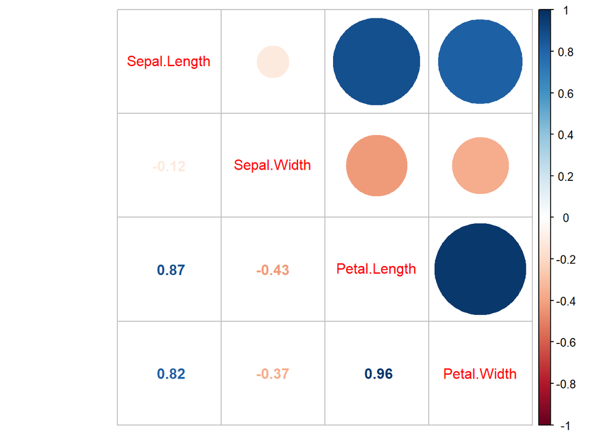

```r
require(corrplot)
corrplot.mixed(cor(iris[,1:4]))
```

## Lab 1: Data Visualization, Expected Value and Covariance Properties

Report your answers to the following questions in an R Markedown file. Submit your answers by the 25th of September 2024, 23:59, on the Fénix webpage.

Add your group number and the students’ name and number of its members in the file:

- **Group Number: 22**
- **Name and Number - Group Member: Antonio Vitor Villas Boas | 105429**

### Exercise 1: Data Visualization

Consider the `crabs` dataset available from the `MASS` library. Based on the example above, do your exploratory analysis and visualization of this dataset. For each output, add an interpretation of the obtained results.

```r
require(MASS)
#?crabs
head(crabs)
```

|  | sp | sex | index | FL | RW | CL | CW | BD |
| --- | --- | --- | --- | --- | --- | --- | --- | --- |
| 1 | B | M | 1 | 8.1 | 6.7 | 16.1 | 19.0 | 7.0 |
| 2 | B | M | 2 | 8.8 | 7.7 | 18.1 | 20.8 | 7.4 |
| 3 | B | M | 3 | 9.2 | 7.8 | 19.0 | 22.4 | 7.7 |
| 4 | B | M | 4 | 9.6 | 7.9 | 20.1 | 23.1 | 8.2 |
| 5 | B | M | 5 | 9.8 | 8.0 | 20.3 | 23.0 | 8.2 |
| 6 | B | M | 6 | 10.8 | 9.0 | 23.0 | 26.5 | 9.8 |

```r
summary(crabs)
```

```
##  sp      sex         index            FL              RW              CL
##  B:100   F:100   Min.   : 1.0   Min.   : 7.20   Min.   : 6.50   Min.   :14.70
##  O:100   M:100   1st Qu.:13.0   1st Qu.:12.90   1st Qu.:11.00   1st Qu.:27.27
##                  Median :25.5   Median :15.55   Median :12.80   Median :32.10
##                  Mean   :25.5   Mean   :15.58   Mean   :12.74   Mean   :32.11
##                  3rd Qu.:38.0   3rd Qu.:18.05   3rd Qu.:14.30   3rd Qu.:37.23
##                  Max.   :50.0   Max.   :23.10   Max.   :20.20   Max.   :47.60
##        CW              BD
##  Min.   :17.10   Min.   : 6.10
##  1st Qu.:31.50   1st Qu.:11.40
##  Median :36.80   Median :13.90
##  Mean   :36.41   Mean   :14.03
##  3rd Qu.:42.00   3rd Qu.:16.60
##  Max.   :54.60   Max.   :21.60
```

```r
describe(crabs)
```

|  | vars | n | mean | sd | median | trimmed | mad | min | max | range | skew | kurtosis | se |
| --- | --- | --- | --- | --- | --- | --- | --- | --- | --- | --- | --- | --- | --- |
| sp* | 1 | 200 | 1.5000 | 0.5012547 | 1.50 | 1.50000 | 0.74130 | 1.0 | 2.0 | 1.0 | 0.00000000 | -2.0099750 | 0.03544406 |
| sex* | 2 | 200 | 1.5000 | 0.5012547 | 1.50 | 1.50000 | 0.74130 | 1.0 | 2.0 | 1.0 | 0.00000000 | -2.0099750 | 0.03544406 |
| index | 3 | 200 | 25.5000 | 14.4670827 | 25.50 | 25.50000 | 18.53250 | 1.0 | 50.0 | 49.0 | 0.00000000 | -1.2189058 | 1.02297723 |
| FL | 4 | 200 | 15.5830 | 3.4953251 | 15.55 | 15.57750 | 3.92889 | 7.2 | 23.1 | 15.9 | 0.01081884 | -0.6499235 | 0.24715681 |
| RW | 5 | 200 | 12.7385 | 2.5733399 | 12.80 | 12.73687 | 2.52042 | 6.5 | 20.2 | 13.7 | 0.02556633 | -0.3304014 | 0.18196261 |
| CL | 6 | 200 | 32.1055 | 7.1189830 | 32.10 | 32.17500 | 7.33887 | 14.7 | 47.6 | 32.9 | -0.07013991 | -0.5985708 | 0.50338812 |
| CW | 7 | 200 | 36.4145 | 7.8719552 | 36.80 | 36.52063 | 7.78365 | 17.1 | 54.6 | 37.5 | -0.09834458 | -0.5995265 | 0.55663129 |
| BD | 8 | 200 | 14.0305 | 3.4247723 | 13.90 | 14.02688 | 3.78063 | 6.1 | 21.6 | 15.5 | 0.01937031 | -0.5976276 | 0.24216797 |

```r
table(crabs$sp, crabs$sex)
```

```
##
##      F  M
##   B 50 50
##   O 50 50
```

```r
describeBy(crabs, list(crabs$sp, crabs$sex))
```

```
##
##  Descriptive statistics by group
## : B
## : F
##       vars  n  mean    sd median trimmed   mad  min  max range  skew kurtosis
## sp       1 50  1.00  0.00   1.00    1.00  0.00  1.0  1.0   0.0   NaN      NaN
## sex      2 50  1.00  0.00   1.00    1.00  0.00  1.0  1.0   0.0   NaN      NaN
## index    3 50 25.50 14.58  25.50   25.50 18.53  1.0 50.0  49.0  0.00    -1.27
## FL       4 50 13.27  2.63  13.15   13.31  2.97  7.2 19.2  12.0 -0.12    -0.72
## RW       5 50 12.14  2.44  12.20   12.15  2.45  6.5 16.9  10.4 -0.10    -0.64
## CL       6 50 28.10  5.92  27.90   28.12  7.12 14.7 40.9  26.2 -0.05    -0.75
## CW       7 50 32.62  6.80  32.35   32.66  7.93 17.1 47.9  30.8 -0.06    -0.69
## BD       8 50 11.82  2.75  11.60   11.79  3.26  6.1 18.1  12.0  0.06    -0.73
##         se
## sp    0.00
## sex   0.00
## index 2.06
## FL    0.37
## RW    0.34
## CL    0.84
## CW    0.96
## BD    0.39
## ------------------------------------------------------------
## : O
## : F
##       vars  n  mean    sd median trimmed   mad  min  max range  skew kurtosis
## sp       1 50  2.00  0.00   2.00    2.00  0.00  2.0  2.0   0.0   NaN      NaN
## sex      2 50  1.00  0.00   1.00    1.00  0.00  1.0  1.0   0.0   NaN      NaN
## index    3 50 25.50 14.58  25.50   25.50 18.53  1.0 50.0  49.0  0.00    -1.27
## FL       4 50 17.59  2.97  18.00   17.73  3.26 10.7 23.1  12.4 -0.33    -0.64
## RW       5 50 14.84  2.35  14.65   14.96  2.45  9.2 20.2  11.0 -0.33    -0.22
## CL       6 50 34.62  5.84  34.70   34.89  6.89 21.4 46.2  24.8 -0.30    -0.57
## CW       7 50 39.04  6.54  39.55   39.38  6.75 24.0 52.5  28.5 -0.36    -0.46
## BD       8 50 15.63  2.75  15.65   15.70  2.82  9.7 21.1  11.4 -0.13    -0.74
##         se
## sp    0.00
## sex   0.00
## index 2.06
## FL    0.42
## RW    0.33
```

[output cut: 30 more lines]

```
## index    3 50 25.50 14.58  25.50   25.50 18.53  1.0 50.0  49.0  0.00    -1.27
## FL       4 50 16.63  3.51  16.70   16.64  3.85  9.1 23.1  14.0  0.00    -0.88
## RW       5 50 12.26  2.20  12.10   12.29  2.15  6.9 16.8   9.9 -0.07    -0.54
## CL       6 50 33.69  7.61  33.35   33.74  7.49 16.7 47.6  30.9  0.00    -0.80
## CW       7 50 37.19  8.39  36.30   37.24  8.45 18.6 52.8  34.2  0.01    -0.80
## BD       8 50 15.32  3.53  15.00   15.35  3.56  7.4 21.6  14.2 -0.01    -0.79
##         se
## sp    0.00
## sex   0.00
## index 2.06
## FL    0.50
## RW    0.31
## CL    1.08
## CW    1.19
## BD    0.50
```

```r
round(cov(crabs[,4:8]),3)
```

```
##        FL     RW     CL     CW     BD
## FL 12.217  8.158 24.357 26.551 11.823
## RW  8.158  6.622 16.355 18.240  7.837
## CL 24.357 16.355 50.680 55.761 23.971
## CW 26.551 18.240 55.761 61.968 26.092
## BD 11.823  7.837 23.971 26.092 11.729
```

```r
round(cor(crabs[,4:8]),3)
```

```
##       FL    RW    CL    CW    BD
## FL 1.000 0.907 0.979 0.965 0.988
## RW 0.907 1.000 0.893 0.900 0.889
## CL 0.979 0.893 1.000 0.995 0.983
## CW 0.965 0.900 0.995 1.000 0.968
## BD 0.988 0.889 0.983 0.968 1.000
```

Both covariance and correlation show that Carapace Length (CL) and Carapace Width (CW) are the most strongly related in the dataset. The covariance is high (55.761), and the correlation is nearly perfect (0.995), indicating that larger carapace length is almost always accompanied by larger carapace width. This implies that these two body dimensions scale together almost linearly as the crabs grow.

The frontal lobe (FL) has very high correlations with all other variables (all above 0.90), especially with body depth (BD at 0.988) and carapace length (CL at 0.979). The covariance values (e.g., 24.357 for FL and CL, 26.551 for FL and CW) are also high, confirming that larger frontal lobes are strongly associated with larger overall body size, particularly longer and wider carapaces.

Although rear width (RW) still shows strong correlations with other variables, especially with frontal lobe width (0.907) and carapace width (0.900), it has relatively lower covariance and correlation compared to other relationships. This suggests that rear width is less tightly linked to overall crab size compared to carapace measurements, even though larger crabs generally still have wider rear widths.

the correlation matrix provides a clearer view of the strength of the linear relationships between variables, while the covariance matrix shows the magnitude of these relationships. Both metrics confirm that carapace length, width, and frontal lobe dimensions are the key indicators of crab size, with rear width playing a somewhat less critical role.

[figure not shown]

```r
# Create a boxplot for Carapace Length (CL) by species and sex
boxplot(crabs$CL ~ crabs$sp * crabs$sex,
        main = "Carapace Length by Species and Sex",
        xlab = "Species and Sex",
        ylab = "Carapace Length",
        names = c("Blue Male", "Blue Female", "Orange Male", "Orange Female"),
        col = c("lightblue", "lightpink", "orange", "lightgreen"))
```

[figure not shown]

```r
# Visualization: Histogram of the continuous variables
hist(crabs$FL, main = "Histogram of Front Limb Length", xlab = "Front Limb Length", col='green', breaks = 15)
```